# FVA analysis for IBD patients

Jan Taubenheim

2022-04-07

```r
require(data.table)
require(lme4)
require(lmerTest)
require(ggplot2)
require(cowplot)
require(clusterProfiler)
require(ComplexUpset)
```

# 1 Introduction

I created context specific models of different IBD patients (longitudinal data) from biopsy samples. Afterwards I used FVA results to gain insights into the reactions which do significantly change with differing disease activities expressed as HB/Mayo scores. To this end I used linear mixed models to explain the HB/Mayo score by the change of flux ranges and centers for each reaction.

# 2 Results

Again I used a clustering to de-correlate the reactions and to reduce the amount of tests.

```r
subsystems <- fread("./Statistics/dat/subsystems.csv")
cluster <- fread("./Statistics/results/FVA_DBSCAN_Cluster.csv")
stats <- fread("./Statistics/results/FVA_LMMsRandomPatient_fullCoefTable.csv")
stats.padj <- stats[coef != "(Intercept)",]
stats.padj[,padj := p.adjust(`Pr(>|t|)`, method = "BH")]
sigs <- stats.padj[padj < 0.05,]
```

## 2.1 Clustering

It might be a good idea to understand what the clustering has done to the data

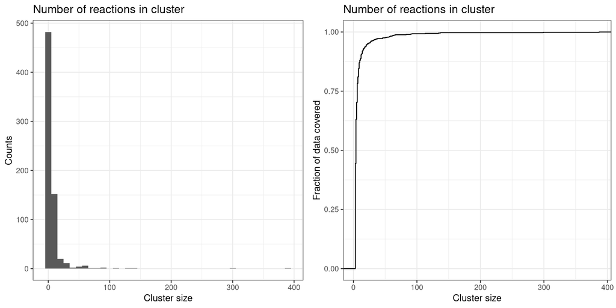

```r
cluster.size <- cluster[cluster != 0, .(cluster_size = .N), by=rep.rxn]
cluster.size.hist <- ggplot(cluster.size, aes(x=cluster_size)) +
    geom_histogram(binwidth = 10) +
    labs(x= "Cluster size", y= "Counts", title = "Number of reactions in cluster")+
    theme_bw()

cluster.size.ecdf <- ggplot(cluster.size, aes(x=cluster_size)) +
    stat_ecdf()+
    labs(x= "Cluster size", y= "Fraction of data covered", title = "Number of reactions in cluster")+
    theme_bw()

cowplot::plot_grid(cluster.size.hist,
                   cluster.size.ecdf,
                   ncol = 2)
```

There are a lot of small clusters with only a few members, while there are also larger ones. But generally, that means clustering was done only on highly correlated reactions. A total of 686 has been generated.

```r
clusterSummary <- data.frame(
                             rxns = nrow(cluster),
                             cluster = max(cluster[,cluster]),
                             rxns_in_cluster = nrow(cluster[cluster != 0,]),
                             reduction = round((max(cluster[,cluster])+nrow(cluster[cluster == 0, ]))/ nrow(cluster),2),
                             significant_rxns_and_cluster = length(unique((sigs[,rxn]))),
                             significant_rxns = nrow(cluster[rep.rxn %in% sigs[,rxn],]), #
                             largest_cluster = max(cluster.size[,cluster_size]),
                             smallest_cluster = min(cluster.size[,cluster_size]),
                             mean_cluster = round(mean(cluster.size[,cluster_size]),2),
                             median_cluster = median(cluster.size[,cluster_size])
                             )
clusterSummary <- t(clusterSummary)
colnames(clusterSummary) <- c("Value")
DT::datatable(clusterSummary)
```

|  | Value |
| --- | --- |
| rxns | 8245 |
| cluster | 686 |
| rxns_in_cluster | 5670 |
| reduction | 0.4 |
| significant_rxns_and_cluster | 510 |
| significant_rxns | 1713 |
| largest_cluster | 387 |
| smallest_cluster | 3 |
| mean_cluster | 8.27 |
| median_cluster | 4 |

## 2.2 Overview

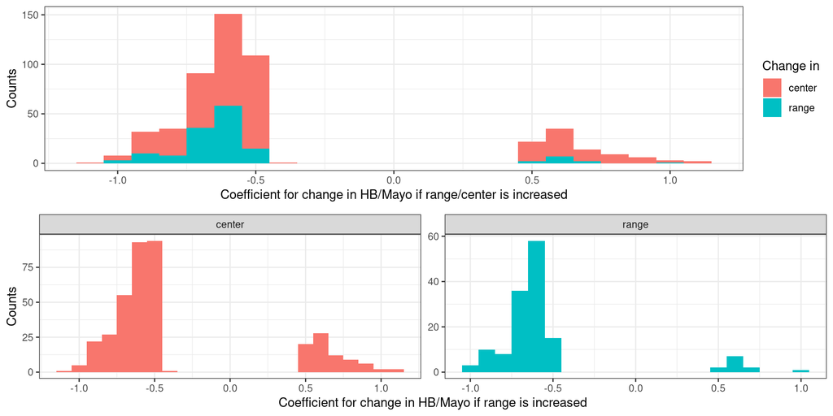

```r
sigs.hist.both <- ggplot(sigs, aes(x=Estimate, fill = coef)) +
    geom_histogram(binwidth=0.1)+
    labs(x = "Coefficient for change in HB/Mayo if range/center is increased",
         y = "Counts",
         fill = "Change in") +
    theme_bw()

sigs.hist.split <- ggplot(sigs, aes(x=Estimate, fill = coef)) +
    geom_histogram(binwidth=0.1)+
    labs(x = "Coefficient for change in HB/Mayo if range is increased",
         y = "Counts",
         fill = "Change in") +
    facet_wrap(~coef, scale = "free")+
    theme_bw() +
    theme(legend.position = "none")

sigs.hist <- plot_grid(sigs.hist.both, sigs.hist.split, ncol = 1)
sigs.hist
```

## 2.3 Subsystems association

To get an overview of what subsystems are associated with the change in HB/Mayo we can associate the different subsystems to the significant reactions.

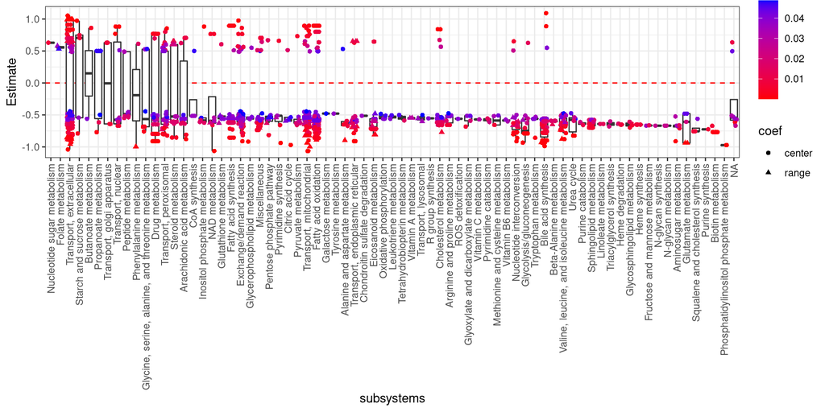

```r
# get all significant reactions
rxns <- unique(sigs[rxn %in% cluster[cluster == 0, rep.rxn],rxn])
rxns <- c(rxns,cluster[cluster != 0 & rep.rxn %in% sigs[,rxn],Rxn])

# get the annotation for these reactions
setkey(subsystems, "reaction")
subs <- subsystems[rxns]

#merge the stats with the reactions - use the clusterID to merge as well
subs <- merge(subs, cluster, by.x = "reaction", by.y = "Rxn", all.x=T)
subs <- merge(subs, sigs, by.x = "rep.rxn", by.y = "rxn")

# create a boxplot of the coefficients per subsystem
subs_order <- subs[,.(mean_est = mean(Estimate)), by = subsystem]
subs[,subsystems := factor(subsystem, levels=unique(subs_order[order(mean_est,decreasing=TRUE), subsystem]))]

subs_jitterplot <- ggplot(subs, aes(x=subsystems, y= Estimate)) +
        geom_hline(yintercept=0, color = "red", linetype=2)+
        geom_boxplot(outlier.shape = NA)+
        geom_jitter(height=0, width=0.3,aes(shape = coef, color = padj))+
        theme_bw()+
        theme(axis.text.x = element_text(angle=90, vjust=0.5, hjust=1))+
        scale_color_gradient(low = "red", high = "blue")
subs_jitterplot
```

## 2.4 Subsystem enrichment

In order to test if and which of the subsystems are significantly associated I will perform an hypergeometric enrichment analysis. Note that I will use simply all reactions which are either significantly associated with the center or the range or both to HB/Mayo values.

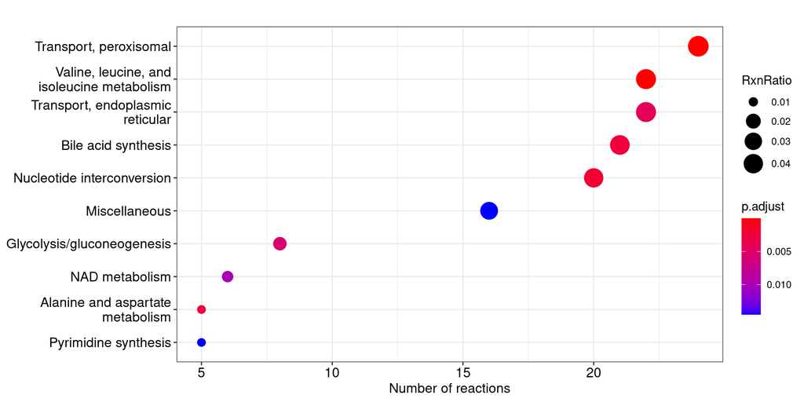

```r
hgt <- enricher(unique(sigs[,rxn]), TERM2GENE = subsystems)
dotplot(hgt,x="Count") +
        labs(x="Number of reactions", size = "RxnRatio")
```

Additionally to the hypergeometric enrichment I will perform a gene set enrichment analysis (GSEA).

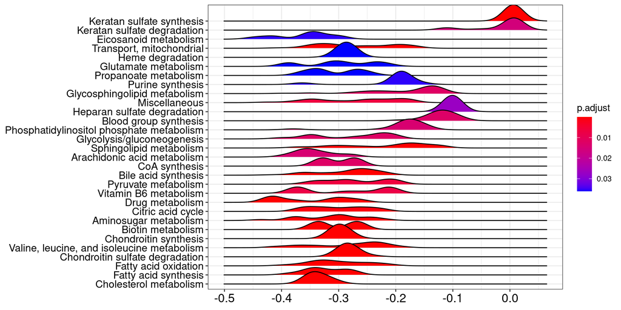

```r
gsea <- readRDS("Statistics/results/FVA_GSEASubsystems.RDS")
ridgeplot(gsea, label_format=90) + theme(axis.text.y= element_text(size = 12))
```

## 2.5 Comparing approaches

Again there is overlap in the methods, so we can have a look at this.

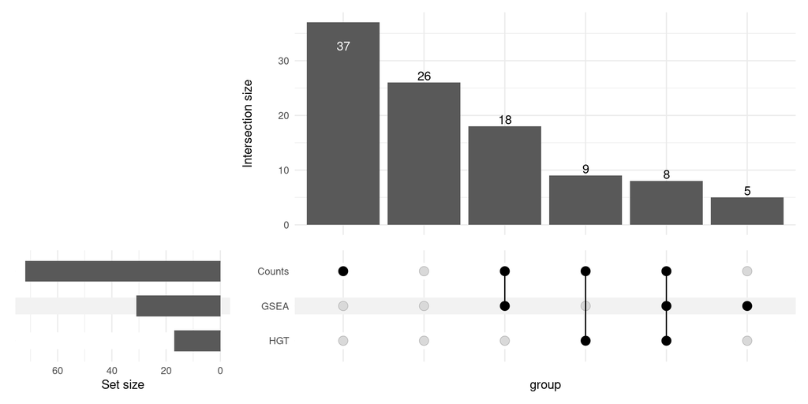

```r
# get the subsystems of each analysis
subsystems.names <- unique(subsystems[,subsystem])
tbl.gsea <- data.table(as.data.frame(gsea))
tbl.hgt <- data.table(as.data.frame(hgt))

mat <- matrix(FALSE, nrow = length(subsystems.names), ncol = 3, dimnames = list(x=subsystems.names, y=c("Counts","HGT","GSEA")))

mat[unique(subs[!is.na(subsystem),subsystem]),"Counts"] <- TRUE
mat[tbl.gsea[,ID], "GSEA"] <- TRUE
mat[tbl.hgt[,ID], "HGT"] <- TRUE

upset(as.data.frame(mat), intersect = colnames(mat))
```

In total there are 8 subsystems which can be found as overlap in all analysis: Transport, mitochondrial, Valine, leucine, and isoleucine metabolism, Propanoate metabolism, Bile acid synthesis, Citric acid cycle, Glycolysis/gluconeogenesis, Miscellaneous, Arachidonic acid metabolism.